# Introdução ao R Markdown para HTML

Lucas S.B. Jordão

13/05/2021

# 1 Introdução

Observe que no cabeçalho YAML, o documento output é: `bookdown::html_document2`. O output em HTML geralmente é indicado como `html_document`. Neste documento, incluímos a rimeira forma, que depende da instalação do interessante pacote **bookdown**, proximamente relacionado ao **R Markdown**, que usa esse mesmo código para produzir livros digitais em formato HTML. Contudo, no presente documento, utilizamos para possibilitar a ferramenta de referência cruzada (Seção 7).

Com um output em HTML, o Markdown pode embutir linguagens CSS e JavaScript.

# 2 Citação

Para escrever uma citação use: `> Texto`.

O código abaixo[^1]…

```
> "*A persistência é o caminho do êxito*"
> **Charles Chaplin**
```

…compila o seguinte:

> “*A persistência é o caminho do êxito*”  
> **Charles Chaplin**

# 3 Código em pedaços

A possibilidade de embutir a linguagem de programação em um documento que utiliza linguagem de marcação traz implicações profundas para a ciência e pesquisa.  
Nesses tipo de documentos, como o *R Markdown*, os códigos de programação são feitos em pedaços (*code chunks*).

```
Esse campo é destinado à apresentação de códigos, mas não são executados para fins de processamento.
```

Para criar um pedaço de código utiliza-se o seguinte código:  
O “r” significa que o código pertence à linguagem R.

````
```{r}
Código R
```
````

Também é possível nomear o pedaço, assim:

````
```{r nome_do_pedaço_de_código}
Código R
```
````

É possível também controlar o output do pedaço do código usando argumantos específicos:

- `echo = TRUE`: Mostra o código e o *output*
- `echo = FALSE`: Mostra apenas o *output*, sem o código
- `include = FALSE`: Apenas roda o código, mas não mostra nem o código nem o *output*
- `warning = TRUE`: Mostra os avisos ao rodar um código
- `warning = FALSE`: Omite os avisos ao rodar um código
- `message = TRUE`: Mostra as mensagens ao rodar um código
- `message = FALSE`: Omite as mensagens ao rodar um código

Exemplo:

````
```{r echo = TRUE, warning = FALSE}
Código R
```
````

No R Studio, para modificar interativamente essas configurações do pedaço de código, clique no ícone da ‘engrenagem’ que aparece no lado direito do bloco de código.

## 3.1 Incluindo botão de copiar código

O pacote klippy permite incluir um botão para copiar todo o código.  
Não se esqueça de instalar o pacote antes.

```r
library(klippy)
klippy(tooltip_message = 'Clique para copiar', tooltip_success = 'Copiado')
```

# 4 Tabelas em HTMLs

Vamos usar o *dataset* (objeto) denominado ‘iris’, incluído no pacote `base` do R:

## 4.1 Estilo básico

```r
library(knitr)
kable(iris[1:6, ], caption = "Tabela 'kable' do pacote 'knitr'")
```

Table 4.1: Tabela ‘kable’ do pacote ‘knitr’

| Sepal.Length | Sepal.Width | Petal.Length | Petal.Width | Species |
| --- | --- | --- | --- | --- |
| 5.1 | 3.5 | 1.4 | 0.2 | setosa |
| 4.9 | 3.0 | 1.4 | 0.2 | setosa |
| 4.7 | 3.2 | 1.3 | 0.2 | setosa |
| 4.6 | 3.1 | 1.5 | 0.2 | setosa |
| 5.0 | 3.6 | 1.4 | 0.2 | setosa |
| 5.4 | 3.9 | 1.7 | 0.4 | setosa |

## 4.2 Estilo clássico

```r
library(kableExtra)
kbl(iris[1:6, ]) %>%
  kable_classic(full_width = T)
```

| Sepal.Length | Sepal.Width | Petal.Length | Petal.Width | Species |
| --- | --- | --- | --- | --- |
| 5.1 | 3.5 | 1.4 | 0.2 | setosa |
| 4.9 | 3.0 | 1.4 | 0.2 | setosa |
| 4.7 | 3.2 | 1.3 | 0.2 | setosa |
| 4.6 | 3.1 | 1.5 | 0.2 | setosa |
| 5.0 | 3.6 | 1.4 | 0.2 | setosa |
| 5.4 | 3.9 | 1.7 | 0.4 | setosa |

## 4.3 Estilo Listrado

```r
kbl(iris[1:6, ]) %>%
  kable_styling(bootstrap_options = "striped")
```

| Sepal.Length | Sepal.Width | Petal.Length | Petal.Width | Species |
| --- | --- | --- | --- | --- |
| 5.1 | 3.5 | 1.4 | 0.2 | setosa |
| 4.9 | 3.0 | 1.4 | 0.2 | setosa |
| 4.7 | 3.2 | 1.3 | 0.2 | setosa |
| 4.6 | 3.1 | 1.5 | 0.2 | setosa |
| 5.0 | 3.6 | 1.4 | 0.2 | setosa |
| 5.4 | 3.9 | 1.7 | 0.4 | setosa |

## 4.4 Estilo Luz Flutuante

```r
kbl(iris[1:6, ]) %>%
  kable_styling(bootstrap_options = "hover")
```

| Sepal.Length | Sepal.Width | Petal.Length | Petal.Width | Species |
| --- | --- | --- | --- | --- |
| 5.1 | 3.5 | 1.4 | 0.2 | setosa |
| 4.9 | 3.0 | 1.4 | 0.2 | setosa |
| 4.7 | 3.2 | 1.3 | 0.2 | setosa |
| 4.6 | 3.1 | 1.5 | 0.2 | setosa |
| 5.0 | 3.6 | 1.4 | 0.2 | setosa |
| 5.4 | 3.9 | 1.7 | 0.4 | setosa |

## 4.5 Estilo Listrado + Luz Flutuante

```r
kbl(iris[1:6, ]) %>%
  kable_styling(bootstrap_options = c("striped", "hover"))
```

| Sepal.Length | Sepal.Width | Petal.Length | Petal.Width | Species |
| --- | --- | --- | --- | --- |
| 5.1 | 3.5 | 1.4 | 0.2 | setosa |
| 4.9 | 3.0 | 1.4 | 0.2 | setosa |
| 4.7 | 3.2 | 1.3 | 0.2 | setosa |
| 4.6 | 3.1 | 1.5 | 0.2 | setosa |
| 5.0 | 3.6 | 1.4 | 0.2 | setosa |
| 5.4 | 3.9 | 1.7 | 0.4 | setosa |

## 4.6 Congelando os títulos das colunas e colorindo as linhas

Para congelar os títulos, usa-se o argumento ‘fixed_thead = T’ na função kable_styling(). Para colorir a linha, usa-se a função ‘row_spec()’ com argumento ‘background = “lightgreen”’. O operador %>% concatena funções que podem ser agrupadas, formando cadeias de funções.

| Sepal.Length | Sepal.Width | Petal.Length | Petal.Width | Species |
| --- | --- | --- | --- | --- |
| 5.1 | 3.5 | 1.4 | 0.2 | setosa |
| 4.9 | 3.0 | 1.4 | 0.2 | setosa |
| 4.7 | 3.2 | 1.3 | 0.2 | setosa |
| 4.6 | 3.1 | 1.5 | 0.2 | setosa |
| 5.0 | 3.6 | 1.4 | 0.2 | setosa |
| 5.4 | 3.9 | 1.7 | 0.4 | setosa |
| 4.6 | 3.4 | 1.4 | 0.3 | setosa |
| 5.0 | 3.4 | 1.5 | 0.2 | setosa |
| 4.4 | 2.9 | 1.4 | 0.2 | setosa |
| 4.9 | 3.1 | 1.5 | 0.1 | setosa |
| 5.4 | 3.7 | 1.5 | 0.2 | setosa |
| 4.8 | 3.4 | 1.6 | 0.2 | setosa |
| 4.8 | 3.0 | 1.4 | 0.1 | setosa |
| 4.3 | 3.0 | 1.1 | 0.1 | setosa |
| 5.8 | 4.0 | 1.2 | 0.2 | setosa |
| 5.7 | 4.4 | 1.5 | 0.4 | setosa |
| 5.4 | 3.9 | 1.3 | 0.4 | setosa |
| 5.1 | 3.5 | 1.4 | 0.3 | setosa |
| 5.7 | 3.8 | 1.7 | 0.3 | setosa |
| 5.1 | 3.8 | 1.5 | 0.3 | setosa |

# 5 Importando dados para um documento R Markdown

Qualquer arquivo pode ser importado para um documento R Markdown, desde que tenha sido gravado como um objeto específico do ambiente de trabalho do R, como o arquivo .rds.

Fundamental na importação do arquivo num documento R Markdown, é que o caminho do arquivo deve estar completo. Do contrário, um erro será mostrado. Nesse caso, observe a direção correta da barra. É possível usar tanto “\\” quanto “/” no caminho do arquivo (e.g. também daria certo escrever: “C:\\R\\R-4.0.0\\working\\Mimosa_RJ.rds”)

```r
Mimosa_RJ <- readRDS("C:/R/R-4.0.0/working/Mimosa_RJ.rds")
kable(Mimosa_RJ[1:20,]) %>%
  kable_styling(bootstrap_options = c("striped", "hover", "condensed"), font_size = 9)
```

| catalogNumber | recordNumber | recordedBy | eventDate | municipality | decimalLatitude | decimalLongitude | scientifname |
| --- | --- | --- | --- | --- | --- | --- | --- |
| CBPM00001014 | 690 | Ribeiro, R.D. | 18/07/2006 | Rio de Janeiro | -22.9397222 | -43.40361 | Mimosa caesalpiniifolia Benth. |
| CBPM00000979 | 669 | Ribeiro, R.D. | 28/06/2006 | Rio de Janeiro | -22.9397222 | -43.40361 | Mimosa bimucronata (DC.) Kuntze |
| IBGE00066949 | 324 | Correia, CMB | 06/03/1993 | Silva Jardim | -22.5000000 | -42.25000 | Mimosa bimucronata (DC.) Kuntze |
| IBGE00075764 | 7390 | Eiten, G | 25/07/1966 | Resende | -22.4711111 | -44.44361 | Mimosa scabrella Benth. |
| IBGE00032002 | 172757 | Soares, CBV | 1990-5 | Petrópolis | -22.5105556 | -43.17722 | Mimosa schomburgkii Benth. |
| HUENF00001249 | 19 | Ribeiro, A.C.C. |  | Rio das Ostras | -22.4283334 | -42.03556 | Mimosa guilandinae (DC.) Barneby |
| HUENF00001378 | 33 | Ribeiro, A.C.C. | 20/06/2002 | Rio das Ostras | -22.4283334 | -42.03556 | Mimosa guilandinae (DC.) Barneby |
| HUENF00001461 | 34 | Ribeiro, A.C.C. | 12/02/2003 | Rio das Ostras | -22.4283334 | -42.03556 | Mimosa guilandinae (DC.) Barneby |
| HUENF00005444 | 160 | Mauad, L.P. | 26/03/2010 | Campos dos Goytacazes | -21.7972222 | -41.44806 | Mimosa sp. |
| RB00162810 |  | A.C.Brade |  | Itatiaia |  | NA | Mimosa monticola Dusén |
| RB00115460 | 105 | D.Fernandes | 23/10/1998 | Armação dos Búzios |  | NA | Mimosa elliptica Benth. |
| RB00522999 | 887 | G. Heiden | 26/09/2007 | Teresópolis |  | NA | Mimosa glaziovii Benth. |
| RB00762045 | 4714 | A. A. M. Barros | 27/06/2012 | Niterói | -22.9666667 | -43.03333 | Mimosa arenosa (Willd.) Poir. var. arenosa |
| RB00475216 | 2854 | C.Porto | 15/01/1936 | Itatiaia |  | NA | Mimosa monticola Dusén |
| RB00586058 | 2 | R. de C. C. Silva | 20/06/1997 | Niterói |  | NA | Mimosa velloziana Mart. |
| RB00588921 | 83 | L. T. Vassal | 14/04/2004 | Niterói |  | NA | Mimosa schomburgkii Benth. |
| RB00476039 | 311 | I.R.Carvalho | 16/04/1984 | Rio de Janeiro |  | NA | Mimosa laticifera Rizzini & A.Mattos |
| RB00871666 | 303 | N.Coqueiro | 20/10/2006 | São Gonçalo |  | NA | Mimosa candollei R.Grether |
| RB00448765 | 755 | A.F. Vaz | 02/09/1990 | Nova Friburgo | -22.5500000 | -42.50000 | Mimosa extensa Benth. var. extensa |
| RB00165455 | 06?38 | Flávio Brito Pereira | 02/10/2000 | Cachoeiras de Macacu | -22.4569444 | -42.81833 | Mimosa paludosa Benth. |

# 6 Adicionando ícones

Para adicionar ícones no documento, instale o pacote `icons`:

```
install.packages("remotes")
remotes::install_github("mitchelloharawild/icons")
download_fontawesome()
```

Há duas formas de adicionar um ícone:

Via pedaço de código:

```
library(icons)
fontawesome("rocket", style = "solid")
```

Veja:

```r
library(icons)
fontawesome("rocket", style = "solid")
```

[output not shown]

OU

Via código dentro de linha (*inline*): `` `r icons::fontawesome(“laugh-wink”, style = “solid”)` ``

Visite: https://fontawesome.com.

# 7 Criando as referências cruzadas

Para utilizar a referência cruzada é preciso utilizar o pacote `bookdown`. Não esqueça de instalar!  
Para realizar a referência cruzada é preciso que a imagem ou tabela tenha um cabeçalho (*caption*).

## 7.1 Figuras

Esta é a figura 7.1.

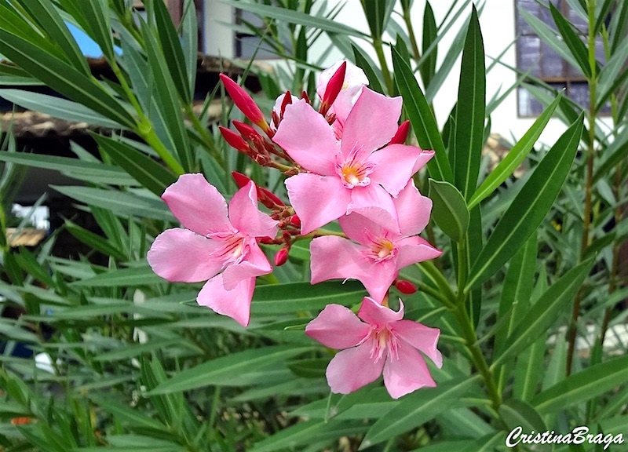

Figure 7.1: Espirradeira. Foto: Cristina Braga.

```r
knitr::include_graphics("espirradeira.png")
```

## 7.2 Tabelas

Esta é a tabela 7.1.

Table 7.1: Tamanho da flor de *Iris sp.*

| Sepal.Length | Sepal.Width | Petal.Length | Petal.Width | Species |
| --- | --- | --- | --- | --- |
| 5.1 | 3.5 | 1.4 | 0.2 | setosa |
| 4.9 | 3.0 | 1.4 | 0.2 | setosa |
| 4.7 | 3.2 | 1.3 | 0.2 | setosa |
| 4.6 | 3.1 | 1.5 | 0.2 | setosa |
| 5.0 | 3.6 | 1.4 | 0.2 | setosa |
| 5.4 | 3.9 | 1.7 | 0.4 | setosa |
| 4.6 | 3.4 | 1.4 | 0.3 | setosa |
| 5.0 | 3.4 | 1.5 | 0.2 | setosa |
| 4.4 | 2.9 | 1.4 | 0.2 | setosa |
| 4.9 | 3.1 | 1.5 | 0.1 | setosa |

## 7.3 Seções e subseções

O seção 7 está com referência cruzada. A subseção 7.3 também.

# 8 Menus colapsáveis e expandíveis

Visite o site [W<sup>3</sup>schools](https://www.w3schools.com). Nele, há diversas elementos de HTML, CSS, JS, etc, prontos para copiar e colar.

## 8.1 Em HTML

### 8.1.1 Triângulo simples

```
<details>
  <summary>**Menu**</summary>
    *Texto*
</details>
```

**Menu**

*Texto*

### 8.1.2 Botão

````
<p>
  <a class="btn btn-primary" data-toggle="collapse" href="#collapseExample1" role="button" aria-expanded="false" aria-controls="collapseExample1">
    **Menu_Botão**
  </a>
</p>
<div class="collapse" id="collapseExample1">
  <div class="card card-body">

  **Texto**
  Abaixo as 15 primeiras linhas do objeto 'iris':


```r
iris[1:15,]
```

```
##    Sepal.Length Sepal.Width Petal.Length Petal.Width Species
## 1           5.1         3.5          1.4         0.2  setosa
## 2           4.9         3.0          1.4         0.2  setosa
## 3           4.7         3.2          1.3         0.2  setosa
## 4           4.6         3.1          1.5         0.2  setosa
## 5           5.0         3.6          1.4         0.2  setosa
## 6           5.4         3.9          1.7         0.4  setosa
## 7           4.6         3.4          1.4         0.3  setosa
## 8           5.0         3.4          1.5         0.2  setosa
## 9           4.4         2.9          1.4         0.2  setosa
## 10          4.9         3.1          1.5         0.1  setosa
## 11          5.4         3.7          1.5         0.2  setosa
## 12          4.8         3.4          1.6         0.2  setosa
## 13          4.8         3.0          1.4         0.1  setosa
## 14          4.3         3.0          1.1         0.1  setosa
## 15          5.8         4.0          1.2         0.2  setosa
```

```r
# OBS: O bloco de código logo acima no documento final em HTML, que mostra o objeto 'iris[1:15,]', não deve ser incluído na versão em código R Markdown (.Rmd).
```

  </div>
</div>
````

**Menu_Botão**

*Texto*  
Abaixo as 15 primeiras linhas do objeto ‘iris’:

```r
iris[1:15,]
```

```
##    Sepal.Length Sepal.Width Petal.Length Petal.Width Species
## 1           5.1         3.5          1.4         0.2  setosa
## 2           4.9         3.0          1.4         0.2  setosa
## 3           4.7         3.2          1.3         0.2  setosa
## 4           4.6         3.1          1.5         0.2  setosa
## 5           5.0         3.6          1.4         0.2  setosa
## 6           5.4         3.9          1.7         0.4  setosa
## 7           4.6         3.4          1.4         0.3  setosa
## 8           5.0         3.4          1.5         0.2  setosa
## 9           4.4         2.9          1.4         0.2  setosa
## 10          4.9         3.1          1.5         0.1  setosa
## 11          5.4         3.7          1.5         0.2  setosa
## 12          4.8         3.4          1.6         0.2  setosa
## 13          4.8         3.0          1.4         0.1  setosa
## 14          4.3         3.0          1.1         0.1  setosa
## 15          5.8         4.0          1.2         0.2  setosa
```

## 8.2 Formulários

### 8.2.1 Input: texto livre

**Enter a Message**

Your input:

### 8.2.2 Input: caixa de seleção unitária

### 8.2.3 Input: caixa de seleção múltipla

[^1]: Não esqueça de deixar uma linha em branco flanqueando esse bloco, acima e abaixo.